# Analysis Summary level_3

## 3.2 Silhouette Analysis

```r
sig_size <- 60

sil_tb <-
  tibble(sig_size = 1:sig_size) %>%
  # slice(1) %>%
  mutate(sil_df = map(sig_size, ~ sig_select(mean_contrast_L3, LEVEL, .x))) %>%
  mutate(sil_df = map(sil_df, ~.x %>% sil_func(LEVEL)))

sil_data <- sil_tb %>%
  unnest(sil_df) %>%
  nest(plot_data = - !!as.symbol(pre(LEVEL)))
```

### 3.2.1 Signature size selection & PCA plot for monocyte derived cells

Signature size selection plot for mono_derived cell:

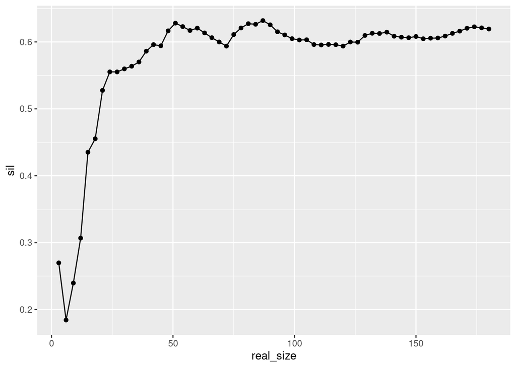

```r
mono_sil <- sil_data %>%
  pluck("plot_data", 1) %>%
  ggplot(aes(real_size, sil)) +
  geom_line() +
  geom_point()

mono_sil
```

```r
sil_data %>%
  pluck("plot_data", 1) %>%
  pull(sil) %>%
  which.max()
```

```
## [1] 29
```

The peak is reached when sig_size = $29$. PCA at sig_size = $29$, \ but silhouette score has only minimal improvement than that when sig_size = $17$:

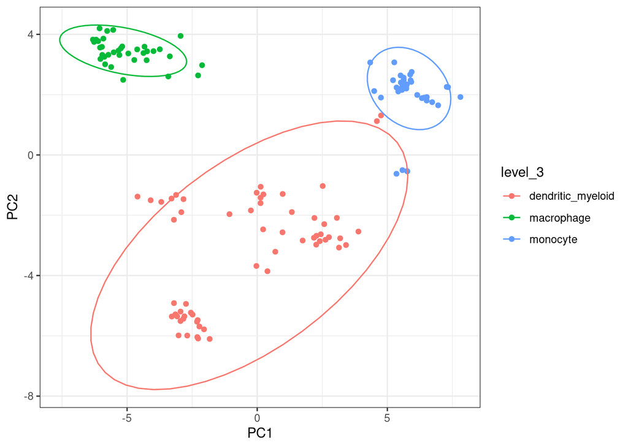

```r
sig_size <- 17

PCA_level3 <- mean_contrast_L3 %>%
  sig_select(LEVEL, sig_size) %>%
  nest(pca= - !!as.symbol(pre(LEVEL))) %>%
  mutate(pca = map(pca, ~ .x %>%
                     distinct(sample, symbol, count_scaled, !!as.symbol(LEVEL)))) %>%
  mutate(pca = map(pca, ~ .x %>%
                     reduce_dimensions(
                       sample, symbol, count_scaled,
                       method = "PCA",
                       action="get",
                       transform = log1p)))

PCA3_mono_sil <- PCA_level3 %>%
  pluck("pca", 1) %>%
  ggplot(aes(x = PC1, y = PC2, colour = !!as.symbol(LEVEL), label = sample)) +
  geom_point() +
  stat_ellipse(type = 't')+
  theme_bw()

PCA3_mono_sil
```

### 3.2.2 Signature size selection & PCA plot for t cells

Signature size selection plot for t cell:

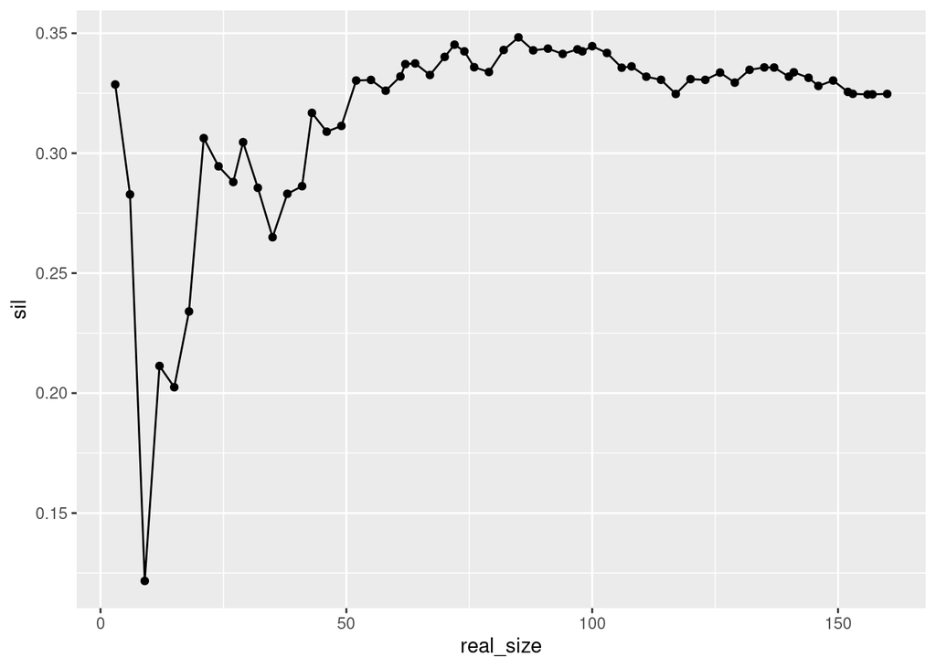

```r
t_sil <- sil_data %>%
  pluck("plot_data", 2) %>%
  ggplot(aes(real_size, sil)) +
  geom_line() +
  geom_point()

t_sil
```

```r
sil_data %>%
  pluck("plot_data", 2) %>%
  pull(sil) %>%
  which.max()
```

```
## [1] 31
```

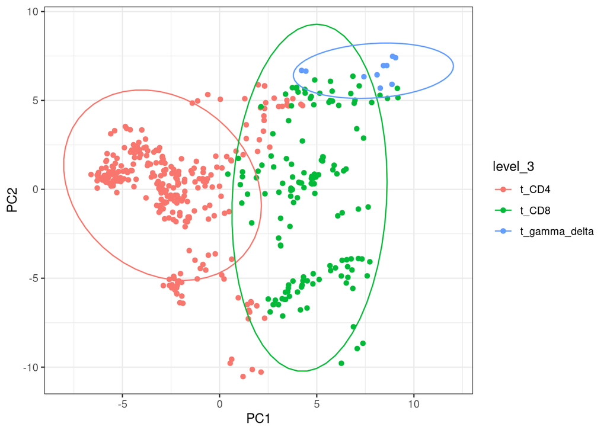

```r
sig_size <- 26

PCA_level3 <- mean_contrast_L3 %>%
  sig_select(LEVEL, sig_size) %>%
  nest(pca= - !!as.symbol(pre(LEVEL))) %>%
  mutate(pca = map(pca, ~ .x %>%
                     distinct(sample, symbol, count_scaled, !!as.symbol(LEVEL)))) %>%
  mutate(pca = map(pca, ~ .x %>%
                     reduce_dimensions(
                       sample, symbol, count_scaled,
                       method = "PCA",
                       action="get",
                       transform = log1p)))

PCA3_t_sil <- PCA_level3 %>%
  pluck("pca", 2) %>%
  ggplot(aes(x = PC1, y = PC2, colour = !!as.symbol(LEVEL), label = sample)) +
  geom_point() +
  stat_ellipse(type = 't')+
  theme_bw()

PCA3_t_sil
```

### 3.2.3 Signature size selection & PCA plot for granulocytes

Signature size selection plot for granulocytes:

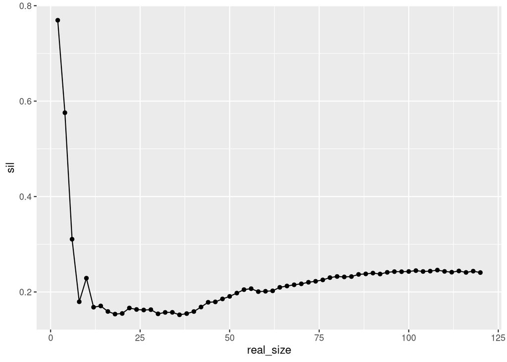

```r
granulocyte_sil <- sil_data %>%
  pluck("plot_data", 3) %>%
  ggplot(aes(real_size, sil)) +
  geom_line() +
  geom_point()

granulocyte_sil
```

```r
sil_data %>%
  pluck("plot_data", 3) %>%
  pull(sil) %>%
  which.max()
```

```
## [1] 1
```

The peak is reached when sig_size = $1$. PCA at sig_size = $1$:

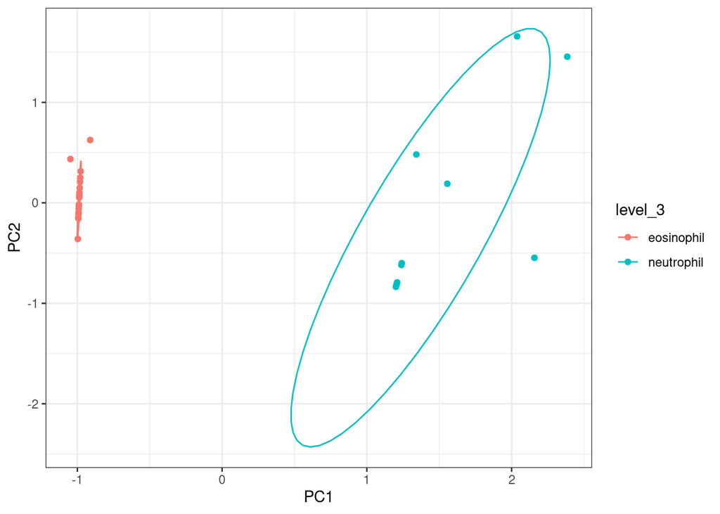

```r
sig_size <- 1

PCA_level3 <- mean_contrast_L3 %>%
  sig_select(LEVEL, sig_size) %>%
  nest(pca= - !!as.symbol(pre(LEVEL))) %>%
  mutate(pca = map(pca, ~ .x %>%
                     distinct(sample, symbol, count_scaled, !!as.symbol(LEVEL)))) %>%
  mutate(pca = map(pca, ~ .x %>%
                     reduce_dimensions(
                       sample, symbol, count_scaled,
                       method = "PCA",
                       action="get",
                       transform = log1p)))

PCA3_granulocyte_sil <- PCA_level3 %>%
  pluck("pca", 3) %>%
  ggplot(aes(x = PC1, y = PC2, colour = !!as.symbol(LEVEL), label = sample)) +
  geom_point() +
  stat_ellipse(type = 't')+
  theme_bw()

PCA3_granulocyte_sil
```

### 3.2.4 Signature size selection & PCA plot for b cells

Signature size selection plot for b cells:

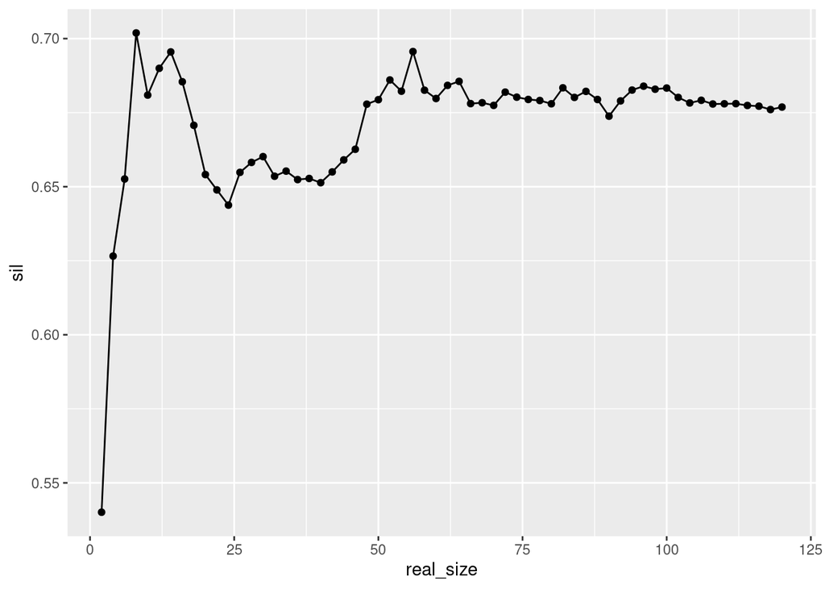

```r
b_sil <- sil_data %>%
  pluck("plot_data", 4) %>%
  ggplot(aes(real_size, sil)) +
  geom_line() +
  geom_point()

b_sil
```

```r
sil_data %>%
  pluck("plot_data", 4) %>%
  pull(sil) %>%
  which.max()
```

```
## [1] 4
```

The peak is reached when sig_size = $4$. PCA at sig_size = $4$:

```r
sig_size <- 4

PCA_level3 <- mean_contrast_L3 %>%
  sig_select(LEVEL, sig_size) %>%
  nest(pca= - !!as.symbol(pre(LEVEL))) %>%
  mutate(pca = map(pca, ~ .x %>%
                     distinct(sample, symbol, count_scaled, !!as.symbol(LEVEL)))) %>%
  mutate(pca = map(pca, ~ .x %>%
                     reduce_dimensions(
                       sample, symbol, count_scaled,
                       method = "PCA",
                       action="get",
                       transform = log1p)))

PCA3_b_sil <- PCA_level3 %>%
  pluck("pca", 4) %>%
  ggplot(aes(x = PC1, y = PC2, colour = !!as.symbol(LEVEL), label = sample)) +
  geom_point() +
  stat_ellipse(type = 't')+
  theme_bw()

PCA3_b_sil
```

[output not shown]

Signature size selection plot for NK cells:

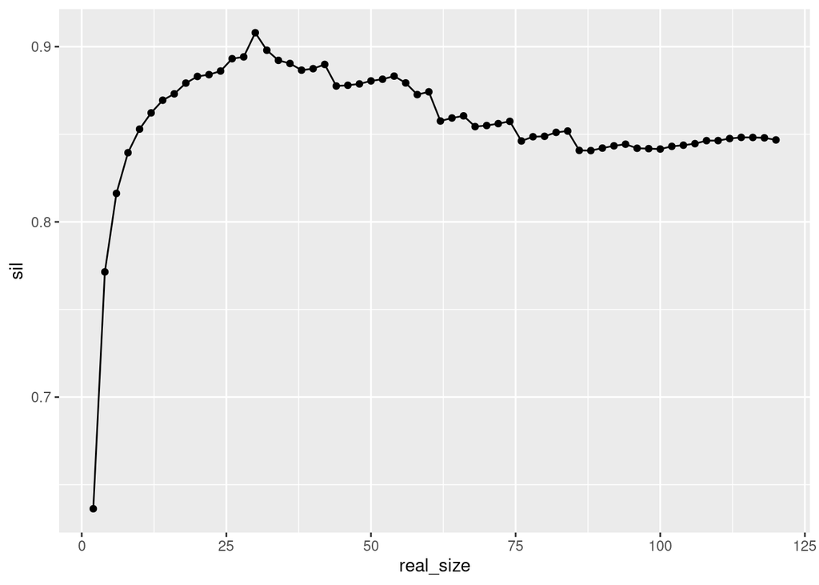

```r
NK_sil <- sil_data %>%
  pluck("plot_data", 5) %>%
  ggplot(aes(real_size, sil)) +
  geom_line() +
  geom_point()

NK_sil
```

```r
sil_data %>%
  pluck("plot_data", 5) %>%
  pull(sil) %>%
  which.max()
```

```
## [1] 15
```

The peak is reached when sig_size = $15$. PCA at sig_size = $15$:

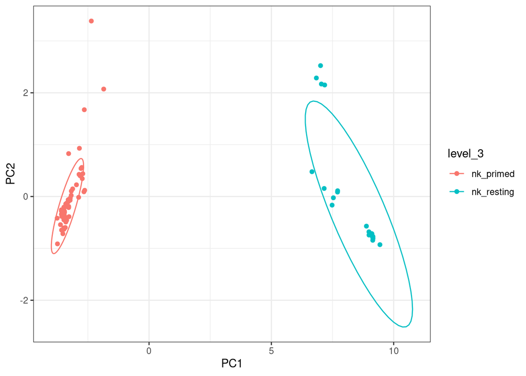

```r
sig_size <- 15

PCA_level3 <- mean_contrast_L3 %>%
  sig_select(LEVEL, sig_size) %>%
  nest(pca= - !!as.symbol(pre(LEVEL))) %>%
  mutate(pca = map(pca, ~ .x %>%
                     distinct(sample, symbol, count_scaled, !!as.symbol(LEVEL)))) %>%
  mutate(pca = map(pca, ~ .x %>%
                     reduce_dimensions(
                       sample, symbol, count_scaled,
                       method = "PCA",
                       action="get",
                       transform = log1p)))

PCA3_NK_sil <- PCA_level3 %>%
  pluck("pca", 5) %>%
  ggplot(aes(x = PC1, y = PC2, colour = !!as.symbol(LEVEL), label = sample)) +
  geom_point() +
  stat_ellipse(type = 't')+
  theme_bw()

PCA3_NK_sil
```